# Esercitazione N.7

Modelli Probit e Logit

Autore/Autrice

Andrea Recine

Data di Pubblicazione

13 maggio 2026

## 1 Setup

```r
library(tidyverse)
library(knitr)
library(modelsummary)
library(fixest)
library(wooldridge)
library(marginaleffects)
```

## 2 Modelli Probit e Logit

Nella precedente esercitazione abbiamo visto il modello lineare di probabilità (LPM) per stimare modelli con variabile dipendente binaria. In questa esercitazione introduciamo i modelli a indice. Nei modelli Probit e Logit, la probabilità è una funzione non lineare dei regressori che garantisce che sia compresa tra 0 e 1. Questa funzione non lineare, che differisce tra Probit e Logit, è una funzione dell’indice lineare $X\beta$.

### 2.1 Probit

**Modello Probit**: Utilizza la funzione di distribuzione cumulativa normale:
$$\Pr(Y=1|X_1,\dots, X_k) = \Phi(\beta_0 + \beta_1 X_1 + \beta_2 X_2 + ... + \beta_k X_k) = \Phi(X\beta)$$

dove $\Phi(z)$ è la funzione di distribuzione cumulativa della normale standard.

$$\Phi(z) = \int_{-\infty}^{z} \frac{1}{\sqrt{2\pi}} e^{-\frac{t^2}{2}} dt$$

L’effetto marginale di una variabile $X_j$ in un modello Probit è dato da:

$$\frac{\partial \Pr(Y=1|X_1,\dots, X_k)}{\partial X_j} = \phi(X\beta) \cdot \beta_j$$

Ed è massimizzato quando $X\beta = 0$, ovvero quando la probabilità predetta è 0.5.

Sia per Logit che per Probit, i coefficienti stimati **non rappresentano** direttamente gli effetti marginali sulla probabilità: $\beta_j$ ne fornisce il segno, ma non la grandezza, che dipende dai valori di tutte le variabili esplicative (a differenza del LPM, dove è costante) e quindi cambia da individuo a individuo.

Usiamo gli stessi regressori del modello LPM per stimare un modello Probit. Ricordiamo che:

| Variabile | Descrizione |
| --- | --- |
| $abuse$ | Variabile dummy (1=Abusa di Alcol, 0=Non abusa). |
| $employ$ | Variabile dipendente dummy (1=Occupato, 0=Non occupato). |
| $married$ | Variabile dummy (1=Sposato, 0=Non sposato). |
| $educ$ | Anni di istruzione. |
| $age$ | Età in anni. |

```r
data(alcohol, package = "wooldridge")
probit_alcohol <- feglm(employ ~ abuse + educ + age + married, data = alcohol, family = 'probit')
modelsummary(list("Employ (Probit)" = probit_alcohol), gof_omit = "AIC|BIC|RMSE")
```

|  | Employ (Probit) |
| --- | --- |
| (Intercept) | 0.495 |
|  | (0.114) |
| abuse | -0.110 |
|  | (0.056) |
| educ | 0.089 |
|  | (0.006) |
| age | -0.018 |
|  | (0.002) |
| married | 0.455 |
|  | (0.045) |
| Num.Obs. | 9822 |
| R2 | 0.064 |
| R2 Adj. | 0.063 |

I coefficienti del modello Probit rappresentano l’effetto sull’indice latente $X\beta$, che è misurato in unità di deviazioni standard della normale standard.

## 3 Modello Logit

**Modello Logit**: Utilizza la funzione logistica per modellare la probabilità:
$$\Pr(Y=1|X_1,\dots, X_k) = \frac{e^{\beta_0 + \beta_1 X_1 + \beta_2 X_2 + ... + \beta_k X_k}}{1 + e^{\beta_0 + \beta_1 X_1 + \beta_2 X_2 + ... + \beta_k X_k}} = \Lambda(X\beta)$$

dove $\Lambda(z) = \frac{e^z}{1 + e^z}$ è la funzione logistica.

Al pari del Probit, l’effetto marginale nel logit è massimo quando la probabilità predetta è 0.5, ovvero quando $X\beta = 0$.

Probit e Logit spesso producono risultati simili. Tuttavia, possono differire nelle code della distribuzione, con il Logit che tende ad avere code più pesanti rispetto al Probit.

```r
logit_alcohol <- feglm(employ ~ abuse + educ + age + married, data = alcohol, family = 'logit')

modelsummary(list("Employ (Logit)" = logit_alcohol),
            gof_omit = "AIC|BIC|RMSE")
```

|  | Employ (Logit) |
| --- | --- |
| (Intercept) | 0.802 |
|  | (0.216) |
| abuse | -0.223 |
|  | (0.105) |
| educ | 0.166 |
|  | (0.011) |
| age | -0.035 |
|  | (0.004) |
| married | 0.859 |
|  | (0.084) |
| Num.Obs. | 9822 |
| R2 | 0.064 |
| R2 Adj. | 0.063 |

### 3.1 Confronto grafico

Per visualizzare la differenza tra LPM, Probit e Logit, possiamo tracciare le tre funzioni $\Pr(Y=1 \mid X\beta)$ in funzione dell’indice lineare $X\beta$:

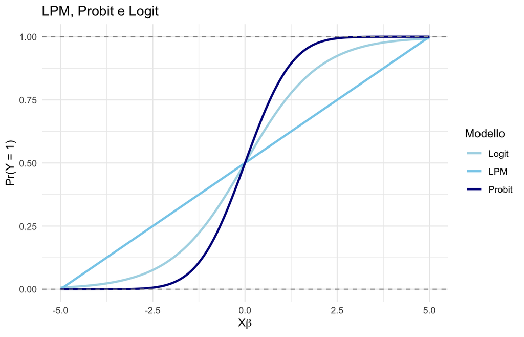

```r
z <- seq(-5, 5, length.out = 400)
curve_df <- tibble(
  z = z,
  Probit = pnorm(z),
  Logit  = plogis(z),
  LPM    = 0.5 + 0.1 * z
) |>
  pivot_longer(-z, names_to = "Modello", values_to = "p")

ggplot(curve_df, aes(x = z, y = p, color = Modello)) +
  geom_line(linewidth = 1) +
  geom_hline(yintercept = c(0, 1), linetype = "dashed", color = "grey60") +
  scale_color_manual(values = c("LPM" = "skyblue",
                                "Probit" = "darkblue",
                                "Logit" = "lightblue")) +
  labs(x = expression(X*beta), y = "Pr(Y = 1)",
       title = "LPM, Probit e Logit") +
  theme_minimal()
```

Si nota che:

- il **LPM** è una retta: per valori estremi di $X\beta$ la probabilità predetta può uscire dall’intervallo $[0,1]$;
- **Probit** e **Logit** restano sempre tra $[0,1]$;
- le due curve sono molto vicine intorno a $X\beta = 0$ (probabilità $\approx 0.5$), ma il **Logit** ha code più pesanti — converge a 0 e 1 più lentamente del Probit.

### 3.2 Probabilità predetta

Una volta stimato il modello Probit, possiamo calcolare la probabilità predetta per un singolo individuo in due passi:

1. costruiamo l’**indice lineare**
   $$X\beta = \beta_0 + \beta_{abuse}\cdot abuse + \beta_{educ}\cdot educ + \beta_{age}\cdot age + \beta_{married}\cdot married;$$
2. applichiamo la funzione:

$$\Pr(employ = 1 \mid X) = \Phi(X\beta).$$

**ImportanteSegno di $X\beta$ e $\Phi(X\beta) \gtrless 0.5$**

La funzione $\Phi$ è la CDF della normale standard, è **strettamente crescente** e $\Phi(0) = 0.5$. Quindi:

- $X\beta > 0 \;\Longleftrightarrow\; \Phi(X\beta) > 0.5$;
- $X\beta < 0 \;\Longleftrightarrow\; \Phi(X\beta) < 0.5$.

Se la probabilità predetta è maggiore o minore di 0.5 basta calcolare il **segno** di $X\beta$.

Lo stesso vale anche per il Logit, solo che al posto di $\Phi$ si usa $\Lambda$ (la funzione logistica), che è anch’essa strettamente crescente e con $\Lambda(0) = 0.5$.

Estraiamo i coefficienti del modello Probit stimato:

```r
b <- coef(probit_alcohol)
b
```

```
#> (Intercept)       abuse        educ         age     married
#>  0.49508051 -0.11039779  0.08943836 -0.01789159  0.45454656
```

Consideriamo due individui con profili opposti:

- **Individuo A**: età $= 35$, istruzione $= 14$ anni, sposato, **non** abusa di alcol.
- **Individuo B**: età $= 55$, istruzione $= 4$ anni, non sposato, abusa di alcol.

**Individuo A**:

```r
xb_A <- b["(Intercept)"] + b["abuse"]*0 + b["educ"]*14 +
        b["age"]*35 + b["married"]*1
unname(xb_A)
```

```
#> [1] 1.575558
```

```r
prob_A <- pnorm(xb_A)
unname(prob_A)
```

```
#> [1] 0.9424362
```

**Individuo B**:

```r
xb_B <- b["(Intercept)"] + b["abuse"]*1 + b["educ"]*4 +
        b["age"]*55 + b["married"]*0
unname(xb_B)
```

```
#> [1] -0.2416015
```

```r
prob_B <- pnorm(xb_B)
unname(prob_B)
```

```
#> [1] 0.4045445
```

Verifichiamo che i valori dei due individui coincidano con quelli ottenuti automaticamente da `predict()`:

```r
predict(probit_alcohol,
        newdata = data.frame(abuse   = c(0,  1),
                             educ    = c(14, 4),
                             age     = c(35, 55),
                             married = c(1,  0)))
```

```
#> [1] 0.9424362 0.4045445
```

Visualizziamo la posizione dei due individui sulla curva $\Phi$, evidenziando la soglia $0.5$ e l’asse verticale $X\beta = 0$:

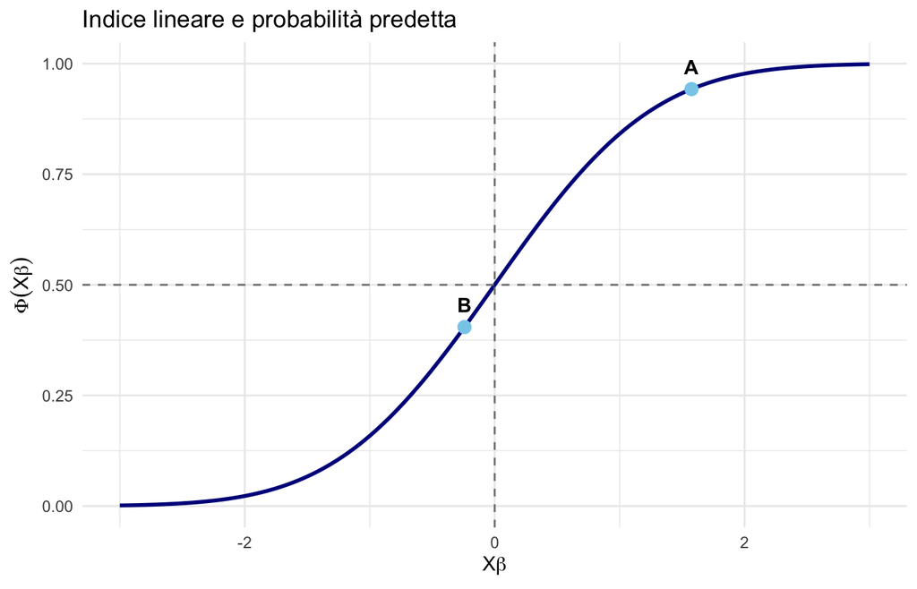

```r
punti <- tibble(
  individuo = c("A", "B"),
  xb        = c(xb_A, xb_B),
  p         = c(prob_A, prob_B)
)

ggplot(tibble(z = seq(-3, 3, length.out = 400)),
       aes(x = z, y = pnorm(z))) +
  geom_line(color = "darkblue", linewidth = 1) +
  geom_hline(yintercept = 0.5, linetype = "dashed", color = "grey50") +
  geom_vline(xintercept = 0,   linetype = "dashed", color = "grey50") +
  geom_point(data = punti, aes(x = xb, y = p),
             color = "skyblue", size = 3) +
  geom_text(data = punti, aes(x = xb, y = p, label = individuo),
            nudge_y = 0.05, fontface = "bold") +
  labs(x = expression(X * beta), y = expression(Phi(X * beta)),
       title = "Indice lineare e probabilità predetta") +
  theme_minimal()
```

A si trova nel ramo destro della curva ($X\beta > 0$, $\Phi > 0.5$), B cade nel ramo sinistro ($X\beta < 0$, $\Phi < 0.5$). Le due linee tratteggiate $X\beta = 0$ e $\Phi = 0.5$ si incrociano nel punto di simmetria della $\Phi$, dove la curva ha la pendenza massima.

### 3.3 Logit: odds

I coefficienti del modello logit rappresentano l’effetto sul log(odds), non sulla probabilità. Un modo per interpretare i coefficienti è come **odds ratio** dopo trasformazione esponenziale (quindi prendendo l’esponenziale del coefficiente)

Infatti, se $p(X_i) = \Lambda(X_i\beta)$, l’odds è definito come:

$$\text{odds}(X_i) = \frac{p(X_i)}{1 - p(X_i)} = e^{X_i\beta}$$

Se prendiamo il logaritmo degli odds, otteniamo:
$$\log(\text{odds}(X_i)) = X_i\beta$$

Il log-odds è una funzione lineare delle variabili esplicative, e i coefficienti $\beta_j$ rappresentano l’effetto di un’unità di aumento in $X_j$ sul log-odds di $Y=1$.

Se aumentiamo $X_j$ di un’unità tenendo fisse le altre variabili, il rapporto tra i nuovi odds e quelli di partenza è l’**odds ratio**:

$$\text{OR}_j = \frac{\text{odds}(X_j + 1)}{\text{odds}(X_j)} = \frac{e^{X\beta + \beta_j}}{e^{X\beta}} = e^{\beta_j}$$

L’odds ratio dipende solo da $\beta_j$ e non dal livello di partenza di $X_j$ né dalle altre variabili: per questo si dice che è **costante rispetto ai livelli di $X$**.

Calcoliamo gli odds ratio per il modello Logit stimato sui dati `alcohol`:

```r
exp(coef(logit_alcohol)) |> round(3)
```

```
#> (Intercept)       abuse        educ         age     married
#>       2.231       0.800       1.181       0.966       2.362
```

**Interpretazione**:

- L’odds ratio per la variabile $abuse$ è 0.8. Aver abusato di alcol fa sì che gli odds di essere occupato diminuiscano di circa il 20% (0.8 - 1 = -0.2) rispetto a chi non ha abusato di alcol.
- L’odds ratio per la variabile $educ$ è 1.18. Un anno in più di istruzione **aumenta** gli odds di essere occupato di circa il 18% (1.18 - 1 = 0.18).

**ImportanteOdds ratio**

L’odds ratio non è un rapporto di probabilità. Un odds ratio di 2 non significa che la probabilità raddoppi; significa che il rapporto «successi su insuccessi» raddoppia. L’odds ratio del logit è costante rispetto ai livelli di $X_i$, mentre l’effetto marginale sulla probabilità non lo è.

## 4 Effetti Marginali Medi (AME) e al punto medio (MEM)

Il calcolo degli effetti marginali è fondamentale per interpretare correttamente i modelli Logit e Probit.

**Effetti Marginali Medi (AME)**: si calcolano gli effetti marginali per ogni osservazione nel dataset e poi si fa la media. Media degli effetti individuali su tutto il campione.

Matematicamente, l’effetto marginale medio (AME) è calcolato come:
$$\overline{\text{AME}} = \frac{1}{n} \sum_{i=1}^{n} \text{ME}_i$$

dove $\text{ME}_i$ è l’effetto marginale calcolato per l’osservazione $i$ e $n$ è il numero totale di osservazioni nel dataset.

**Effetti Marginali al punto medio (MEM)**: si calcolano gli effetti marginali utilizzando i valori medi delle variabili esplicative. Quindi il MEM calcola l’effetto marginale valutando tutte le variabili alla loro media campionaria

**NotaNota**

Nel LPM: L’effetto marginale è semplicemente il coefficiente $\beta_j$:
$$\frac{\partial \Pr(Y=1|X_1,\dots, X_k)}{\partial X_j} = \beta_j$$

### 4.1 Calcolo manuale

Quando $X_j$ è una variabile dummy, l’effetto marginale è dato dalla differenza tra la probabilità predetta quando $X_j=1$ e quando $X_j=0$. Per calcolare l’effetto marginale di `abuse` sui modelli Probit e Logit, possiamo seguire questi passaggi:

Effetto Marginale abuso alcol, modello probit:

```r
# Creazione di due dataset: uno con abuse=1 per tutti e uno con abuse=0 per tutti
alcohol_tmp1 <- alcohol
alcohol_tmp0 <- alcohol

# Impostiamo abuse=1 per tutti nel primo dataset
alcohol_tmp1$abuse <- 1
# Impostiamo abuse=0 per tutti nel secondo dataset
alcohol_tmp0$abuse <- 0

# Calcolo delle probabilità predette per il modello logit
proba_employ_probit <- predict(probit_alcohol, newdata = alcohol_tmp1)
proba_nonemploy_probit <- predict(probit_alcohol, newdata = alcohol_tmp0)

# Calcolo dell'effetto marginale medio (differenza media nelle probabilità predette)
ame_manual_probit <- mean(proba_employ_probit - proba_nonemploy_probit)
print(paste("Effetto marginale medio manuale (Probit):", round(ame_manual_probit, 4)))
```

```
#> [1] "Effetto marginale medio manuale (Probit): -0.0194"
```

Per il modello logit:

```r
# Calcolo delle probabilità predette per il modello logit
proba_employ_logit <- predict(logit_alcohol, newdata = alcohol_tmp1)
proba_nonemploy_logit <- predict(logit_alcohol, newdata = alcohol_tmp0)

# Calcolo dell'effetto marginale medio (differenza media nelle probabilità predette)
ame_manual_logit <- mean(proba_employ_logit - proba_nonemploy_logit)
print(paste("Effetto marginale medio manuale (Logit):", round(ame_manual_logit, 4)))
```

```
#> [1] "Effetto marginale medio manuale (Logit): -0.0206"
```

- Secondo il modello Probit, abusare di alcol riduce la probabilità di essere occupato di 1.9 p.p.
- Secondo il modello Logit, abusare di alcol riduce la probabilità di essere occupato di 2.1 p.p.

L’approccio dell’effetto marginale medio è generalmente considerato più robusto, perché tiene conto di come l’effetto di $abuse$ può variare a seconda delle altre caratteristiche degli individui nel campione.

### 4.2 Con `marginaleffects`

Gli effetti marginali medi calcolati con `marginaleffects` sono identici a quelli calcolati manualmente in precedenza. Il vantaggio di utilizzare `marginaleffects` in questo caso è che otteniamo automaticamente anche gli errori standard permettendo una valutazione della significatività statistica dell’effetto (senza opzioni aggiuntive gli errori standard sono calcolati con il metodo delta).

La funzione `avg_slopes` senza l’opzione `newdata` calcola gli effetti marginali medi, ovvero calcola l’effetto marginale per ogni osservazione nel dataset e poi ne fa la media. Questo approccio tiene conto della distribuzione reale delle variabili nel campione.

```r
all_effects_logit <- avg_slopes(logit_alcohol)
all_effects_probit <- avg_slopes(probit_alcohol)
```

Effetti marginali medi (AME) per il modello Logit:

```r
all_effects_logit
```

```
#>
#>     Term Contrast Estimate Std. Error     z Pr(>|z|)     S    2.5 %    97.5 %
#>  abuse      1 - 0  -0.0206   0.010322 -2.00   0.0456   4.5 -0.04086 -0.000403
#>  age        dY/dX  -0.0030   0.000312 -9.60   <0.001  70.1 -0.00361 -0.002387
#>  educ       dY/dX   0.0144   0.000971 14.87   <0.001 163.8  0.01254  0.016343
#>  married    1 - 0   0.0907   0.010430  8.69   <0.001  58.0  0.07022  0.111100
#>
#> Type: response
```

e per il modello Probit:

```r
all_effects_probit
```

```
#>
#>     Term Contrast Estimate Std. Error     z Pr(>|z|)     S   2.5 %    97.5 %
#>  abuse      1 - 0 -0.01939   0.010338 -1.88   0.0607   4.0 -0.0397  0.000869
#>  age        dY/dX -0.00298   0.000313 -9.53   <0.001  69.1 -0.0036 -0.002370
#>  educ       dY/dX  0.01492   0.000998 14.95   <0.001 165.4  0.0130  0.016873
#>  married    1 - 0  0.08945   0.010104  8.85   <0.001  60.0  0.0696  0.109250
#>
#> Type: response
```

```r
# Tabella con modelsummary
modelsummary(list("Logit (AME)" = all_effects_logit,
            "Probit (AME)" = all_effects_probit), gof_omit = "AIC|BIC|RMSE|R2|Adj")
```

|  | Logit (AME) | Probit (AME) |
| --- | --- | --- |
| abuse | -0.021 | -0.019 |
|  | (0.010) | (0.010) |
| age | -0.003 | -0.003 |
|  | (0.000) | (0.000) |
| educ | 0.014 | 0.015 |
|  | (0.001) | (0.001) |
| married | 0.091 | 0.089 |
|  | (0.010) | (0.010) |
| Num.Obs. | 9822 | 9822 |

Gli effetti sono vicini a quelli stimati con il modello LPM.

### 4.3 Effetti Marginali al Punto Medio (MEM)

In alternativa all’AME, possiamo calcolare l’effetto marginale fissando le variabili esplicative alla loro **media campionaria**. Con `marginaleffects` basta passare `newdata = "mean"`:

```r
mem_probit <- avg_slopes(probit_alcohol, newdata = "mean")
mem_logit  <- avg_slopes(logit_alcohol,  newdata = "mean")

modelsummary(
  list("Probit (AME)" = all_effects_probit,
       "Probit (MEM)" = mem_probit,
       "Logit (AME)"  = all_effects_logit,
       "Logit (MEM)"  = mem_logit),
  gof_omit = "AIC|BIC|RMSE|R2|Adj"
)
```

|  | Probit (AME) | Probit (MEM) | Logit (AME) | Logit (MEM) |
| --- | --- | --- | --- | --- |
| abuse | -0.019 | -0.017 | -0.021 | -0.018 |
|  | (0.010) | (0.009) | (0.010) | (0.009) |
| age | -0.003 | -0.003 | -0.003 | -0.002 |
|  | (0.000) | (0.000) | (0.000) | (0.000) |
| educ | 0.015 | 0.013 | 0.014 | 0.012 |
|  | (0.001) | (0.001) | (0.001) | (0.001) |
| married | 0.089 | 0.090 | 0.091 | 0.088 |
|  | (0.010) | (0.010) | (0.010) | (0.010) |
| Num.Obs. | 9822 | 9822 | 9822 | 9822 |

Per visualizzare la differenza, calcoliamo l’effetto marginale di ciascuna variabile **per ogni osservazione** del campione (con `slopes()` invece di `avg_slopes()`) e sovrapponiamo l’effetto marginale al punto medio (MEM):

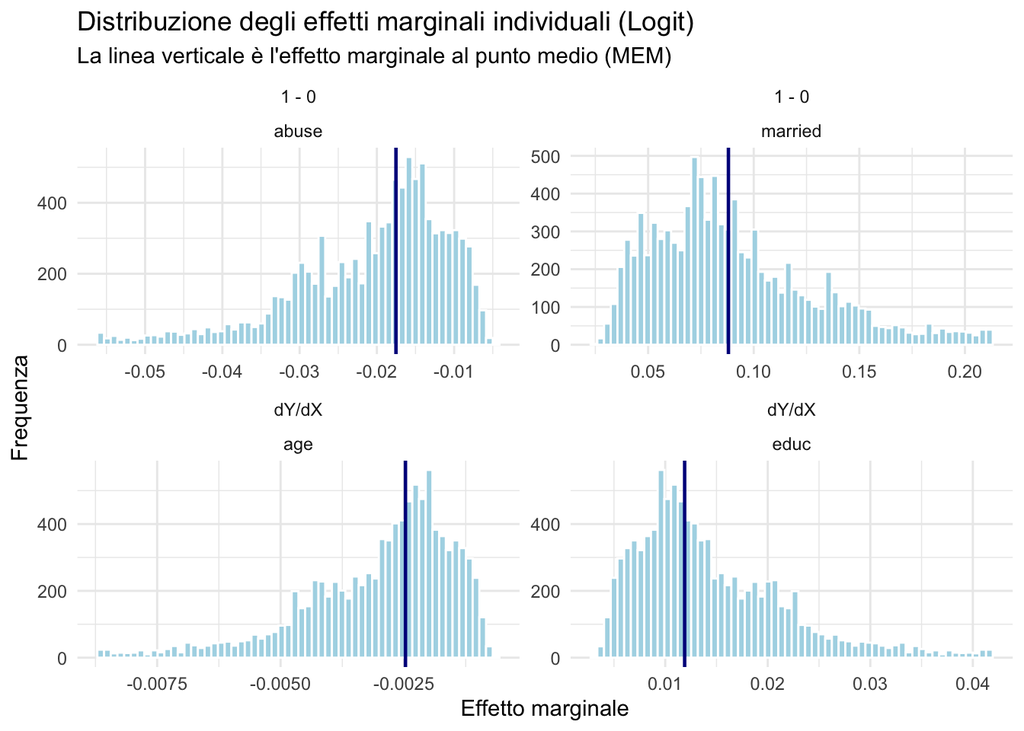

```r
slopes_logit <- slopes(logit_alcohol)

ggplot(slopes_logit, aes(x = estimate)) +
  geom_histogram(bins = 60, fill = "lightblue", color = "white") +
  geom_vline(data = mem_logit, aes(xintercept = estimate),
             color = "darkblue", linewidth = 0.8) +
  facet_wrap(contrast ~ term, scales = "free") +
  labs(title = "Distribuzione degli effetti marginali individuali (Logit)",
       subtitle = "La linea verticale è l'effetto marginale al punto medio (MEM)",
       x = "Effetto marginale",
       y = "Frequenza") +
  theme_minimal()
```

Ogni istogramma mostra la distribuzione degli effetti marginali individuali ($\text{ME}_i$) calcolati per ciascuna osservazione del campione: l’**AME** è la loro media, mentre il **MEM** (linea verticale) è l’effetto calcolato in un singolo punto — quello con tutte le $X$ poste alla media. Quando la distribuzione è asimmetrica o ha code lunghe, AME e MEM possono divergere sensibilmente.

Lo stesso grafico, ma con l’**AME** (media degli effetti individuali) come linea verticale:

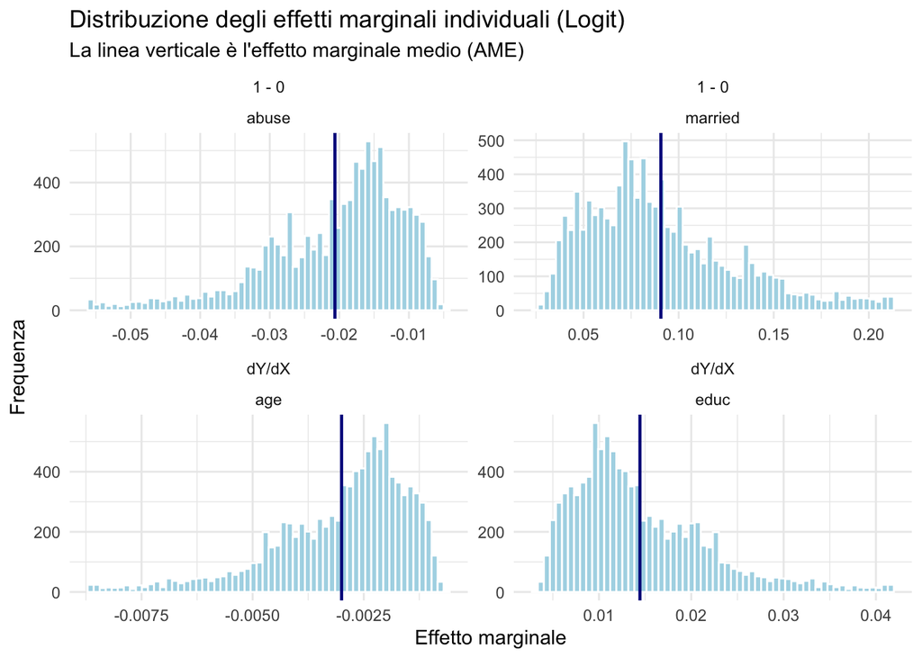

```r
ggplot(slopes_logit, aes(x = estimate)) +
  geom_histogram(bins = 60, fill = "lightblue", color = "white") +
  geom_vline(data = all_effects_logit, aes(xintercept = estimate),
             color = "darkblue", linewidth = 0.8) +
  facet_wrap(contrast ~ term, scales = "free") +
  labs(title = "Distribuzione degli effetti marginali individuali (Logit)",
       subtitle = "La linea verticale è l'effetto marginale medio (AME)",
       x = "Effetto marginale",
       y = "Frequenza") +
  theme_minimal()
```

L’AME cade nel “centro di massa” della distribuzione (è la media aritmetica degli $\text{ME}_i$), mentre il MEM corrisponde al valore della funzione $\phi(X\beta)\cdot \beta_j$ valutata in un solo punto. In questo dataset AME e MEM sono numericamente vicini per tutte le variabili. Il MEM è però **meno interpretabile per le dummy** (`abuse`, `married`): la media di una dummy è un valore frazionario (es. una “frazione” di sposato) che non corrisponde a un individuo realmente osservato.

**Interpretazione** degli effetti marginali medi (AME) del modello Probit:

- Aver abusato di alcol riduce la probabilità di essere occupati di 1.9 punti percentuali
- Un anno in più di istruzione aumenta la probabilità di essere occupati 1.5 punti percentuali
- Essere sposato aumenta la probabilità di essere occupato di 8.9 punti percentuali

## 5 Confronto LPM, Probit e Logit

In questa sezione confrontiamo i risultati dei modelli LPM con gli effetti marginali medi (AME) dei modelli Probit e Logit per i dataset `alcohol` e `crime1`.

### 5.1 dataset `alcohol`

```r
reg_lpm_alcohol <- feols(employ ~ abuse + educ + age + married, data = alcohol, vcov = "hetero")
modelsummary(list("Employ (LPM)" = reg_lpm_alcohol, "Employ AME (Probit)" = all_effects_probit, "Employ AME (Logit)" = all_effects_logit), gof_omit = "AIC|BIC|RMSE|R2 Adj.")
```

|  | Employ (LPM) | Employ AME (Probit) | Employ AME (Logit) |
| --- | --- | --- | --- |
| (Intercept) | 0.741 |  |  |
|  | (0.022) |  |  |
| abuse | -0.018 | -0.019 | -0.021 |
|  | (0.011) | (0.010) | (0.010) |
| educ | 0.017 | 0.015 | 0.014 |
|  | (0.001) | (0.001) | (0.001) |
| age | -0.003 | -0.003 | -0.003 |
|  | (0.000) | (0.000) | (0.000) |
| married | 0.084 | 0.089 | 0.091 |
|  | (0.009) | (0.010) | (0.010) |
| Num.Obs. | 9822 | 9822 | 9822 |
| R2 | 0.045 | 0.064 | 0.064 |

**Interpretazione dei risultati**:

I tre modelli danno risultati molto simili:

- Aver abusato di alcol è associato a una probabilità di essere occupato inferiore di circa 1.8 punti percentuali rispetto a un uomo che non ha abusato di alcol, a parità di età, anni di istruzione e stato coniugale. L’effetto marginale medio di $abuse$ nei modelli Probit e Logit indica che aver abusato di alcol riduce la probabilità di essere occupati rispettivamente di 1.9 e 2.1 punti percentuali.
- Un anno in più di istruzione è associato a un aumento della probabilità di essere occupato di 1.7 punti percentuali a parità delle altre variabili. L’effetto marginale medio di $educ$ nei modelli Probit e Logit indica che un anno in più di istruzione aumenta la probabilità di essere occupati rispettivamente di 1.5 e 1.4 punti percentuali.

### 5.2 dataset `crime1`

Le variabili sono:

| Variabile | Descrizione |
| --- | --- |
| $pcnv$ | Proporzione di arresti precedenti che hanno portato a una condanna. |
| $avgsen$ | Sentenza media scontata da condanne precedenti (in mesi). |
| $tottime$ | Totale dei mesi trascorsi in prigione dai 18 anni in poi, prima del 1986. |
| $ptime86$ | Mesi trascorsi in prigione nel 1986. |
| $qemp86$ | Numero di trimestri in cui l’uomo è stato impiegato nel 1986. |
| $black$ | Variabile dummy (1=Persona di colore, 0=Altra). |
| $hispan$ | Variabile dummy (1=Persona di origine ispanica, 0=Altra). |

```r
data("crime1", package = "wooldridge")
head(crime1)
```

```
#>   narr86 nfarr86 nparr86 pcnv avgsen tottime ptime86 qemp86 inc86 durat black
#> 1      0       0       0 0.38   17.6    35.2      12      0   0.0     0     0
#> 2      2       2       0 0.44    0.0     0.0       0      1   0.8     0     0
#> 3      1       1       0 0.33   22.8    22.8       0      0   0.0    11     1
#> 4      2       2       1 0.25    0.0     0.0       5      2   8.8     0     0
#> 5      1       1       0 0.00    0.0     0.0       0      2   8.1     1     0
#> 6      0       0       0 1.00    0.0     0.0       0      4  97.6     0     0
#>   hispan born60 pcnvsq pt86sq    inc86sq
#> 1      0      1 0.1444    144    0.00000
#> 2      1      0 0.1936      0    0.64000
#> 3      0      1 0.1089      0    0.00000
#> 4      1      1 0.0625     25   77.44000
#> 5      0      0 0.0000      0   65.61001
#> 6      0      1 1.0000      0 9525.75977
```

```r
crime1 <- crime1 %>%
  mutate(arrested = ifelse(narr86 > 0, 1, 0))



reg_lpm_crime <- feols(arrested ~ pcnv + avgsen + tottime + ptime86 + qemp86 + black + hispan, data = crime1, vcov = "hetero")
modelsummary(list("Arrested" = reg_lpm_crime), gof_omit = "AIC|BIC|RMSE|R2 Adj.")
```

|  | Arrested |
| --- | --- |
| (Intercept) | 0.380 |
|  | (0.020) |
| pcnv | -0.152 |
|  | (0.019) |
| avgsen | 0.005 |
|  | (0.006) |
| tottime | -0.003 |
|  | (0.004) |
| ptime86 | -0.024 |
|  | (0.003) |
| qemp86 | -0.038 |
|  | (0.005) |
| black | 0.170 |
|  | (0.026) |
| hispan | 0.096 |
|  | (0.021) |
| Num.Obs. | 2725 |
| R2 | 0.068 |

I modelli Probit e Logit per il dataset `crime1`:

```r
probit_crime <- feglm(arrested ~ pcnv + avgsen + tottime + ptime86 + qemp86 + black + hispan, data = crime1, family = 'probit')
logit_crime <- feglm(arrested ~ pcnv + avgsen + tottime + ptime86 + qemp86 + black + hispan, data = crime1, family = 'logit')

modelsummary(list("Arrested (LPM)" = reg_lpm_crime, "Arrested (Probit)" = probit_crime, "Arrested (Logit)" = logit_crime), gof_omit = "AIC|BIC|RMSE|R2 Adj.")
```

|  | Arrested (LPM) | Arrested (Probit) | Arrested (Logit) |
| --- | --- | --- | --- |
| (Intercept) | 0.380 | -0.284 | -0.464 |
|  | (0.020) | (0.057) | (0.095) |
| pcnv | -0.152 | -0.528 | -0.880 |
|  | (0.019) | (0.070) | (0.122) |
| avgsen | 0.005 | 0.017 | 0.027 |
|  | (0.006) | (0.021) | (0.035) |
| tottime | -0.003 | -0.009 | -0.014 |
|  | (0.004) | (0.017) | (0.028) |
| ptime86 | -0.024 | -0.086 | -0.140 |
|  | (0.003) | (0.017) | (0.031) |
| qemp86 | -0.038 | -0.120 | -0.199 |
|  | (0.005) | (0.017) | (0.028) |
| black | 0.170 | 0.497 | 0.824 |
|  | (0.026) | (0.072) | (0.118) |
| hispan | 0.096 | 0.309 | 0.522 |
|  | (0.021) | (0.065) | (0.109) |
| Num.Obs. | 2725 | 2725 | 2725 |
| R2 | 0.068 | 0.061 | 0.060 |

Non possiamo interpretare direttamente i coefficienti di Probit e Logit, ma possiamo calcolare gli effetti marginali medi (AME) per confrontarli con i coefficienti del LPM:

```r
ame_crime_probit <- avg_slopes(probit_crime)
ame_crime_logit <- avg_slopes(logit_crime)

ame_crime_probit
```

```
#>
#>     Term Contrast Estimate Std. Error     z Pr(>|z|)    S    2.5 %   97.5 %
#>  avgsen     dY/dX  0.00530    0.00655  0.81    0.418  1.3 -0.00753  0.01813
#>  black      1 - 0  0.16978    0.02576  6.59   <0.001 34.4  0.11929  0.22026
#>  hispan     1 - 0  0.10081    0.02177  4.63   <0.001 18.1  0.05814  0.14348
#>  pcnv       dY/dX -0.16520    0.02149 -7.69   <0.001 45.9 -0.20732 -0.12308
#>  ptime86    dY/dX -0.02682    0.00538 -4.98   <0.001 20.6 -0.03737 -0.01627
#>  qemp86     dY/dX -0.03771    0.00516 -7.30   <0.001 41.7 -0.04782 -0.02759
#>  tottime    dY/dX -0.00291    0.00519 -0.56    0.575  0.8 -0.01309  0.00727
#>
#> Type: response
```

```r
ame_crime_logit
```

```
#>
#>     Term Contrast Estimate Std. Error      z Pr(>|z|)    S    2.5 %  97.5 %
#>  avgsen     dY/dX  0.00496    0.00657  0.756    0.450  1.2 -0.00791  0.0178
#>  black      1 - 0  0.17028    0.02575  6.613   <0.001 34.6  0.11981  0.2208
#>  hispan     1 - 0  0.10198    0.02193  4.650   <0.001 18.2  0.05900  0.1450
#>  pcnv       dY/dX -0.16406    0.02218 -7.396   <0.001 42.7 -0.20754 -0.1206
#>  ptime86    dY/dX -0.02615    0.00577 -4.529   <0.001 17.4 -0.03746 -0.0148
#>  qemp86     dY/dX -0.03711    0.00512 -7.242   <0.001 41.0 -0.04716 -0.0271
#>  tottime    dY/dX -0.00259    0.00525 -0.493    0.622  0.7 -0.01288  0.0077
#>
#> Type: response
```

```r
modelsummary(list("Arrested (LPM)" = reg_lpm_crime, "Arrested (Probit AME)" = ame_crime_probit, "Arrested (Logit AME)" = ame_crime_logit), gof_omit = "AIC|BIC|RMSE|R2 Adj.")
```

|  | Arrested (LPM) | Arrested (Probit AME) | Arrested (Logit AME) |
| --- | --- | --- | --- |
| (Intercept) | 0.380 |  |  |
|  | (0.020) |  |  |
| pcnv | -0.152 | -0.165 | -0.164 |
|  | (0.019) | (0.021) | (0.022) |
| avgsen | 0.005 | 0.005 | 0.005 |
|  | (0.006) | (0.007) | (0.007) |
| tottime | -0.003 | -0.003 | -0.003 |
|  | (0.004) | (0.005) | (0.005) |
| ptime86 | -0.024 | -0.027 | -0.026 |
|  | (0.003) | (0.005) | (0.006) |
| qemp86 | -0.038 | -0.038 | -0.037 |
|  | (0.005) | (0.005) | (0.005) |
| black | 0.170 | 0.170 | 0.170 |
|  | (0.026) | (0.026) | (0.026) |
| hispan | 0.096 | 0.101 | 0.102 |
|  | (0.021) | (0.022) | (0.022) |
| Num.Obs. | 2725 | 2725 | 2725 |
| R2 | 0.068 | 0.061 | 0.060 |

**Interpretazione dei risultati**:

- Un aumento di $pcnv$ di 0.01 (1 punto percentuale in più di arresti precedenti che hanno portato a condanna) è associato a una probabilità di essere arrestati inferiore di 0.152 punti percentuali, a parità delle altre variabili. L’effetto marginale medio di $pcnv$ nei modelli Probit e Logit indica che lo stesso aumento riduce la probabilità di essere arrestati rispettivamente di 0.165 e 0.164 punti percentuali.
- Un trimestre in più di occupazione nel 1986 è associato a una probabilità di essere arrestati inferiore di 3.8 punti percentuali a parità delle altre variabili. L’effetto marginale medio di $qemp86$ nei modelli Probit e Logit indica che un trimestre in più riduce la probabilità di essere arrestati rispettivamente di 3.8 e 3.7 punti percentuali.
- A parità delle altre variabili, un uomo di colore ha una probabilità di essere arrestato superiore di 17.0 punti percentuali rispetto a un uomo bianco/altra etnia. L’effetto marginale medio di $black$ nei modelli Probit e Logit è praticamente identico al LPM (17.0 punti percentuali in entrambi).